# Logistic regression

Loading libraries and data

```r
setwd("~/IODS-project/data")
library(dplyr)
library(ggplot2)
library(GGally)
alc <- read.csv("alc.csv", header = TRUE)
```

### Exploring the structure

The data set contains 382 observations of 35 variables. The variables cover each student´s status. There is information about themself, their family,their school performance, drinking habbits and other.

```r
str(alc)
```

```
## 'data.frame':    382 obs. of  35 variables:
##  $ school    : Factor w/ 2 levels "GP","MS": 1 1 1 1 1 1 1 1 1 1 ...
##  $ sex       : Factor w/ 2 levels "F","M": 1 1 1 1 1 2 2 1 2 2 ...
##  $ age       : int  18 17 15 15 16 16 16 17 15 15 ...
##  $ address   : Factor w/ 2 levels "R","U": 2 2 2 2 2 2 2 2 2 2 ...
##  $ famsize   : Factor w/ 2 levels "GT3","LE3": 1 1 2 1 1 2 2 1 2 1 ...
##  $ Pstatus   : Factor w/ 2 levels "A","T": 1 2 2 2 2 2 2 1 1 2 ...
##  $ Medu      : int  4 1 1 4 3 4 2 4 3 3 ...
##  $ Fedu      : int  4 1 1 2 3 3 2 4 2 4 ...
##  $ Mjob      : Factor w/ 5 levels "at_home","health",..: 1 1 1 2 3 4 3 3 4 3 ...
##  $ Fjob      : Factor w/ 5 levels "at_home","health",..: 5 3 3 4 3 3 3 5 3 3 ...
##  $ reason    : Factor w/ 4 levels "course","home",..: 1 1 3 2 2 4 2 2 2 2 ...
##  $ nursery   : Factor w/ 2 levels "no","yes": 2 1 2 2 2 2 2 2 2 2 ...
##  $ internet  : Factor w/ 2 levels "no","yes": 1 2 2 2 1 2 2 1 2 2 ...
##  $ guardian  : Factor w/ 3 levels "father","mother",..: 2 1 2 2 1 2 2 2 2 2 ...
```

[output cut: 21 more lines]

### Chosen variables and their effect on alcohol consumption

Absences: I would expect an individual with higher absence to also have a higher alcohol consumption (positive)  
G3: An individual with high grades could have a lower than average alcohol consumption (negative)  
freetime: With higher free time, higher alcohol consumption (positive)  
studytime: A lot of after school hours spend studying might suggest a lower alcohol consumption (negative)

First, we´ll explore the proposed relationships numerically. I´ll create a dataframe of the chosen variables plus alc_use.

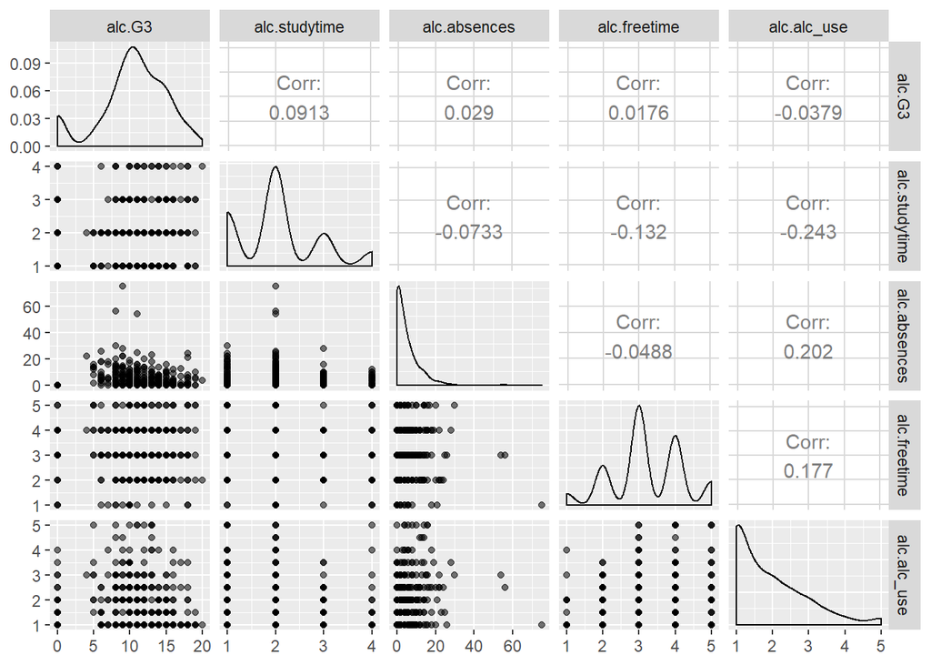

```r
chosen <- data.frame(alc$G3, alc$studytime, alc$absences, alc$freetime, alc$alc_use)
ggpairs(chosen,
        mapping = aes(alpha = 0.6),
        lower = list(combo = wrap("facethist", bins = 30))
        )
```

```r
summary(lm(alc_use ~ G3 + studytime + freetime + absences, data = alc))
```

```
##
## Call:
## lm(formula = alc_use ~ G3 + studytime + freetime + absences,
##     data = alc)
##
## Residuals:
##     Min      1Q  Median      3Q     Max
## -2.3049 -0.6876 -0.2020  0.4840  3.6727
##
## Coefficients:
##              Estimate Std. Error t value Pr(>|t|)
## (Intercept)  1.773181   0.236074   7.511 4.29e-13 ***
## G3          -0.005821   0.010242  -0.568  0.57009
## studytime   -0.239617   0.057406  -4.174 3.72e-05 ***
## freetime     0.160331   0.048851   3.282  0.00113 **
## absences     0.025374   0.006294   4.031 6.71e-05 ***
## ---
## Signif. codes:  0 '***' 0.001 '**' 0.01 '*' 0.05 '.' 0.1 ' ' 1
##
## Residual standard error: 0.932 on 377 degrees of freedom
## Multiple R-squared:  0.119,  Adjusted R-squared:  0.1097
## F-statistic: 12.73 on 4 and 377 DF,  p-value: 9.916e-10
```

Results of the regression confirm the findings in the graph overview and my hypotheses that freetime and absences positively influence alcohol consumption and that studytime negatively. Grades on the other hand do not seem connected to the alcohol consumption.

### Logistic regression

```r
m <- glm(high_use ~ absences + studytime + G3 + freetime, data = alc, family = "binomial")
summary(m)
```

```
##
## Call:
## glm(formula = high_use ~ absences + studytime + G3 + freetime,
##     family = "binomial", data = alc)
##
## Deviance Residuals:
##     Min       1Q   Median       3Q      Max
## -2.4341  -0.8278  -0.6222   1.0692   2.1562
##
## Coefficients:
##             Estimate Std. Error z value Pr(>|z|)
## (Intercept) -1.19000    0.60223  -1.976 0.048155 *
## absences     0.06618    0.01782   3.715 0.000203 ***
## studytime   -0.53725    0.15835  -3.393 0.000692 ***
## G3          -0.01482    0.02612  -0.567 0.570477
## freetime     0.34345    0.12513   2.745 0.006057 **
## ---
## Signif. codes:  0 '***' 0.001 '**' 0.01 '*' 0.05 '.' 0.1 ' ' 1
##
## (Dispersion parameter for binomial family taken to be 1)
##
##     Null deviance: 462.21  on 381  degrees of freedom
## Residual deviance: 419.95  on 377  degrees of freedom
## AIC: 429.95
##
## Number of Fisher Scoring iterations: 4
```

Summary of the logistic regression does not provide an easily predictable outcome therefore I will calculate te odds ratios and theire respective confidence intervals.

```r
OR <- coef(m) %>% exp
# compute confidence intervals (CI)
CI <- exp(confint(m))
# print out the odds ratios with their confidence intervals
cbind(OR, CI)
```

```
##                    OR      2.5 %    97.5 %
## (Intercept) 0.3042226 0.09185394 0.9790195
## absences    1.0684242 1.03423550 1.1086617
## studytime   0.5843507 0.42431180 0.7905026
## G3          0.9852894 0.93648533 1.0377979
## freetime    1.4098080 1.10699420 1.8099160
```

Interpretation: With increase of absence by 1, the odds of observing high usage of alcohol increase by 6.8%. With increase of studytime by 1, the odds of observing high usage descrease by 41.6%. With increase of freetime by 1, the odds of observing high usage increase by 41% (this makes sense in relation to studytime, obviously). With increase of G3 by 1, the odds of observing high usage decrease by 1.5% (negligable).

The confidence intervals are intervals where the odds ratio will be with 95% certainty located. In comparison with the lm model, glm suggest much higher effect of free/study time on alcohol consumption than absences do. LM model showed more similar effects.

```r
# predict() the probability of high_use
probabilities <- predict(m, type = "response")

# add the predicted probabilities to 'alc'
alc <- alc %>%
  mutate(probability = probabilities) %>%
  mutate(prediction = probability > 0.5)

# tabulate the target variable versus the predictions
table(high_use = alc$high_use, prediction = alc$prediction)
```

```
##         prediction
## high_use FALSE TRUE
##    FALSE   258   12
##    TRUE     90   22
```

The table shows that we have 12 false positives or Type I error and 90 false negatives or Type II error.

```r
#Proportion of inaccurately classified individuals
102/382
```

```
## [1] 0.2670157
```

It mean that in 26.7% cases, the model would predict an incorrect outcome. Comparing to the datacamp model (25.6%), my performs even worse.